# Pair Quiz

Rodriguez, Adrian Enrico D.

7/30/2021

# Pair Quiz

## Question 1

### *An article in the Journal of Sound and Vibration [“Measurement of Noise-Evoked Blood Pressure by Means of Averaging Method: Relation between Blood Pressure Rise and PSL” (1991, Vol. 151(3), pp. 383-394)] described a study investigating the relationship between noise exposure and hypertension. The following data are representative of those reported in the article.*

#### **A. Draw a scatter diagram of y (blood pressure rise in millimeters of mercury) versus x (sound pressure level in decibels). Does a simple linear regression model seem reasonable in this situation?**

```r
  y <- c(1, 0,  1,  2,  5,  1,  4,  6,  2,  3,  5,  4,  6,  8,  4,  5,  7,  9,  7,  6)
  x <- c(60,    63, 65, 70, 70, 70, 80, 90, 80, 80, 85, 89, 90, 90, 90, 90, 94, 100, 100, 100)

  plot(x, y, pch = 16, cex = 1, col = "blue", main = "Relation between Blood Pressure Rise and PSL", xlab = "Sound Pressure Level (dB)", ylab = "Blood Pressure Rise (mmHg)")
  lm(y ~ x)
```

```
##
## Call:
## lm(formula = y ~ x)
##
## Coefficients:
## (Intercept)            x
##    -10.1315       0.1743
```

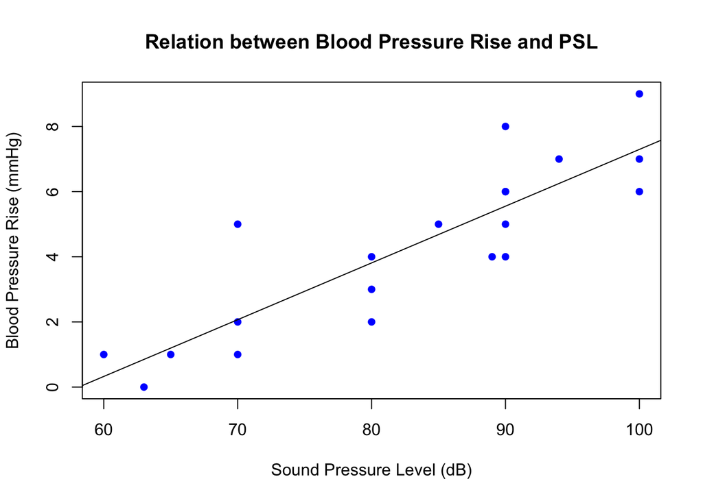

```r
  abline(lm(y ~ x))
```

**Table A.1** *Scatter Diagram of x and y*

As seen in the scatter plot diagram in *Table A.1*, it is **reasonable to use a simple linear regression model** as there is a clear linear relationship present between variable x (sound pressure level) and y (blood pressure). For specificity, there is a direct relationship between both variables as when sound pressure level increases, so does the blood pressure.

#### **B. Fit the simple linear regression model using least squares. Find an estimate of $\sigma^2$**

##### For Simple Linear Regression Model:

Given the set of x and y values, we can determine the simple linear regression model using the **least squares method.** This method is best represented by the equation:

$\hat{y}=\hat{\beta_0}+\hat{\beta_1}x$  
*wherein:*  
$\hat{y}$ is the rise of blood pressure measured in mmHG  
$x$ is the sound pressure in dB  
$\beta_{0}$ and $\beta_1$ are the estimates for regression coefficients

It is worth taking note that this is **reminiscent of the slope intercept form** $y=mx+b$.

With that, we would have to solve for the following summations at $n=20$:

**For $S_xx$**
$$S_xx = \sum_{i = 1}^{n} x_i^2 - \frac{(\sum_{i = 1}^{n} x_i)^2}{n}$$
**For $S_xy$**
$$S_xy = \sum_{i = 1}^{n} x_i y_i - \frac{(\sum_{i = 1}^{n} x_i)(\sum_{i = 1}^{n} y_i)}{n}$$
We then plug in the values we have already solved for as follows:
**For $S_xx$**

$$S_xx = \sum_{i = 1}^{n} x_i^2 - \frac{(\sum_{i = 1}^{n} x_i)^2}{n}$$
$$S_xx = 140,176 - \frac{(1,656)^2}{20}$$
$S_xx = 3,059$

**For $S_xy$**

$$S_xy = \sum_{i = 1}^{n} x_i y_i - \frac{(\sum_{i = 1}^{n} x_i)(\sum_{i = 1}^{n} y_i)}{n}$$
$$S_xy = 7,654 - \frac{(1,656)(86)}{20}$$
$$S_xy = 533.2$$

Now that both have been solved for, we can now **calculate the estimates for regression coefficients as follows:**

**For $\hat{\beta_1}$**
$$\hat{\beta_1}= \frac{S_xy}{S_xx}$$
$$\hat{\beta_1}= \frac{533.2}{3,059.2}$$
$$\hat{\beta_1}= 0.1742939$$
**For $\hat{\beta_0}$**
$$\hat{\beta_0}=\overline{y}-\hat{\beta_1} \overline{x}$$
$$\hat{\beta_0}=4.3 - (0.1742939)(82.8)$$
$$\hat{\beta_0}=-10.1315349$$
This leaves with the equation for the best fit line or **the fitted simple linear regression model:**

$\hat{y}=0.1742939331x-10.13153766$

##### For estimating $\sigma^2$:

We will use the formula:
$$\sigma^2 = \frac{SS_E}{n-2}$$

$SS_E$ can be solved through R as follows:

```r
SSE <- lm(y~x)

sum(resid(SSE)^2)
```

```
## [1] 31.26647
```

Since we already have the value of $SS_E$, we can proceed with attaining $\sigma^2$ by plugging it into the equation former equation:

$$\sigma^2 = \frac{31.26647}{20-2}$$

$$\sigma^2 = 1.737026111$$

With that, we can conclude that **the estimated variance is $\sigma^2=1.737026111$**

#### **C. Find the predicted mean rise in blood pressure level associated with a sound pressure level of 85 decibels.**

Given the fitted simple line regression model, we can further obtain other useful data such predicting the mean rise in blood pressure given a particular pressure level. If we try to predict blood pressure level mean rise at 85 dB, we get the following solution:

$\hat{y}=0.1742939331x-10.13153766$  
$\hat{y}=0.1742939331(85)-10.13153766$  
$\hat{y}=4.683446654$

The answer we solved for is 4.683446654 or approximately 5. With that, we can conclude by saying that the **estimated mean rise in blood pressure level at sound pressure level of 85 dB is 5mmHg**.